# DataAnalysis

Hayden Wainwright

1/23/2020

# Data Analysis of Species Limb Width and Limb Length

## Initial Analysis

I will start by first loading in any packages I will need. Specifically I will need to use dplyr, knitr and ggplot2.

```r
library(dplyr)
```

```r
library(ggplot2)
library(knitr)
```

I will now load in the data from the measurmeent file as the object MData

```r
MData <- read.csv("Data/measurement.csv", row.names = 1)
```

I wanted to change the collumn names to a 3 letter short form of Spc for speices, LmL for Limb length, LmW for limb width, UnW for units of width, and UnL for units of length.

```r
MData <- rename(MData, Spc =Species, LmW =Limb.Width, UnW =unitsW, LmL =Limb.Length, UnL =unitsL)
```

## Volume of Limbs

I also want to calcume the volume of the limbs. To do this I needed to correct the numerical variable for each species’ limb width and length with the units assigned to it. This is down below using the conditional element selection function ifelse(). I then reassigned the units for the dimensions of the limbs to all be cm after the correction was made.

```r
MData$LmW <- ifelse(MData$UnW == "cm", 1, 0.1)*MData$LmW

MData$LmL <- ifelse(MData$UnL == "cm", 1, 0.1)*MData$LmL

MData$UnW <- "cm"

MData$UnL <- "cm"
```

```r
MData <- mutate(MData, Volume = pi*LmL*((LmW/2)^2))

MData
```

```
##                      Spc        LmW UnW        LmL UnL       Volume
## 1        Ursus maritimus  4.0994287  cm  68.659634  cm   906.229196
## 2        Chrysemys picta  0.8917155  cm   2.987406  cm     1.865678
## 3       Falco perefrinus 15.4976120  cm  19.442975  cm  3667.601684
## 4    Salvenlinus alpinus 20.9603332  cm  11.415988  cm  3939.124805
## 5     Psedacris crucifer  1.4401743  cm  14.001349  cm    22.808140
## 6  Pantherophis guttatus  0.8599168  cm  89.056011  cm    51.720889
## 7  Cardinalis cardinalis  1.1886172  cm   7.077308  cm     7.853116
## 8           Quercus alba  9.5525860  cm  28.045968  cm  2010.028568
## 9         Acer saccharum 19.2585975  cm 184.948248  cm 53875.264611
## 10       Rosa Gallicanae  2.7251911  cm   7.947301  cm    46.355733
```

## Grouping Data by Plants and Animals

It was decided to group the species as either animal or plant. A collumn was added to denote this distinction and the data were then grouped by this distinction.

```r
MData$Type <- c("Animal", "Animal", "Animal", "Animal","Animal","Animal","Animal", "Plant", "Plant", "Plant")

SpeciesType <- group_by(MData, Type)
```

I then wanted to see how the length, width, and volume of limbs varied between plants and animals studied. To this end, a table was created displaying the mean and standard deviation of the aforementioned traits.

```r
TraitsByGroup <- summarize(SpeciesType, Limb.Length.AVG = mean(LmL), Limb.Length.SD = sd(LmL), Limb.Width.AVG = mean(LmW), Limb.Width.SD = sd(LmW), Volume.AVG = mean(Volume), Volume.SD = sd(Volume))

 kable(TraitsByGroup, caption = "Table 1.0 Average (AVG) and standard deiation (SD) of limb width, length, and volume for a series of species grouped by plants and animals")
```

Table 1.0 Average (AVG) and standard deiation (SD) of limb width, length, and volume for a series of species grouped by plants and animals

| Type | Limb.Length.AVG | Limb.Length.SD | Limb.Width.AVG | Limb.Width.SD | Volume.AVG | Volume.SD |
| --- | --- | --- | --- | --- | --- | --- |
| Animal | 30.37724 | 34.03206 | 6.419685 | 8.295098 | 1228.172 | 1790.422 |
| Plant | 73.64717 | 96.91200 | 10.512125 | 8.308364 | 18643.883 | 30527.065 |

## Plotting

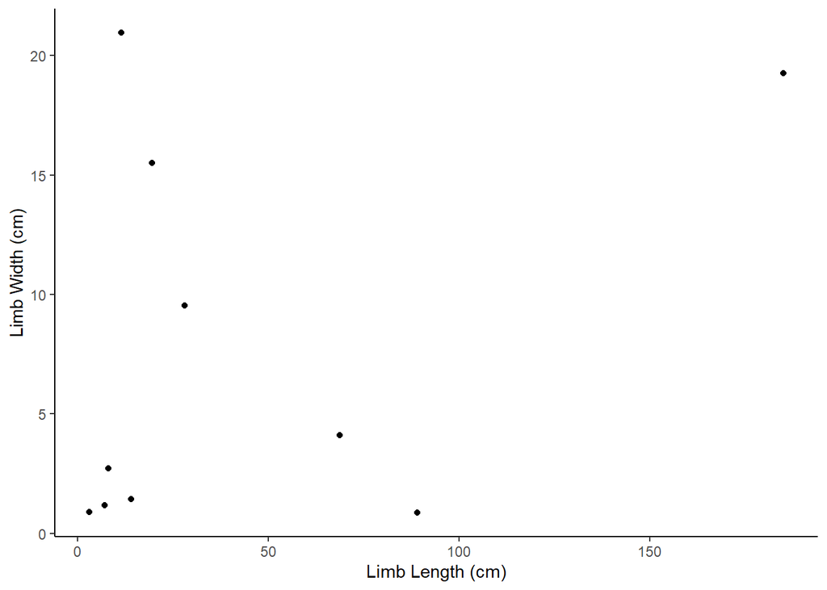

```r
Limb.Graph1 <- ggplot(data = MData, aes(x=LmL, y=LmW))+
  geom_point()+
  labs(x="Limb Length (cm)", y="Limb Width (cm)")+
  theme_classic()

print(Limb.Graph1)
```

Now, I am interested in only plotting the width and length that correspond to limbs with above-average volume. To this end, I first calculated the mean limb volume and seperated my data based on whether the volume for each row was above or below the mean. I then only plotted the data for points corresponding to above average volume.

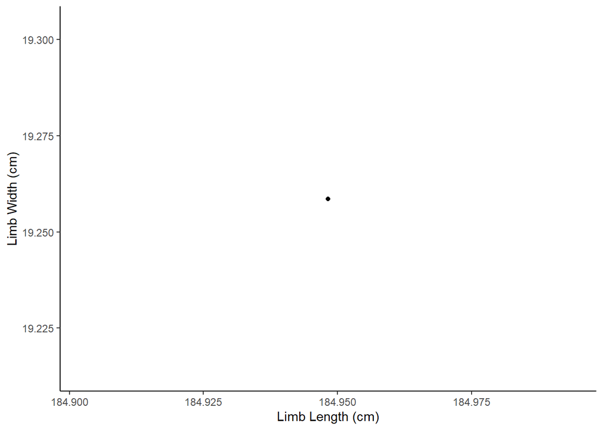

```r
Volume.AVG <- mean(MData$Volume)

Above.AVG.Volume <- filter(MData, Volume>Volume.AVG)

Above.AVG.Graph <- qplot(LmL, LmW, data = Above.AVG.Volume, xlab ="Limb Length (cm)", ylab = "Limb Width (cm)")+ theme_classic()

print(Above.AVG.Graph)
```

Finally, I would like a table that displays only the species and their respective limb volumes that correspond to a volume less than the average. To do this I filtered my data to only include species below the average volume and then created a table using the function kable.

```r
Lower.AVG.Volume <- filter(MData, Volume < Volume.AVG)

Lower.AVG.Volume <- data.frame("Species" = Lower.AVG.Volume$Spc, "Volume" = Lower.AVG.Volume$Volume)

kable(Lower.AVG.Volume, align = 'c', caption = "Table 2. Species name and limb volume for species with below average limb volume")
```

Table 2. Species name and limb volume for species with below average limb volume

| Species | Volume |
| --- | --- |
| Ursus maritimus | 906.229195 |
| Chrysemys picta | 1.865678 |
| Falco perefrinus | 3667.601684 |
| Salvenlinus alpinus | 3939.124806 |
| Psedacris crucifer | 22.808140 |
| Pantherophis guttatus | 51.720889 |
| Cardinalis cardinalis | 7.853116 |
| Quercus alba | 2010.028568 |
| Rosa Gallicanae | 46.355733 |